# 2_Enhanced_Visualization

### Outline Style (New in v1.2.0)

You can change the violin plot style from filled to outline:

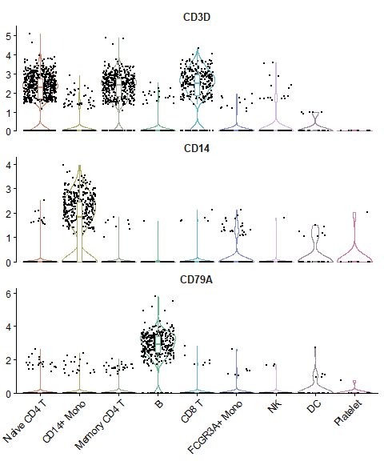

```r
VlnPlot2(pbmc, features = genes, style = "outline", ncol = 1)
```

### Adding Mean and Median Lines (New in v1.1.0)

For genes with low expression where boxplot might be hard to interpret (e.g., when median and quartiles overlap at zero), you can add mean/median lines for better visualization:

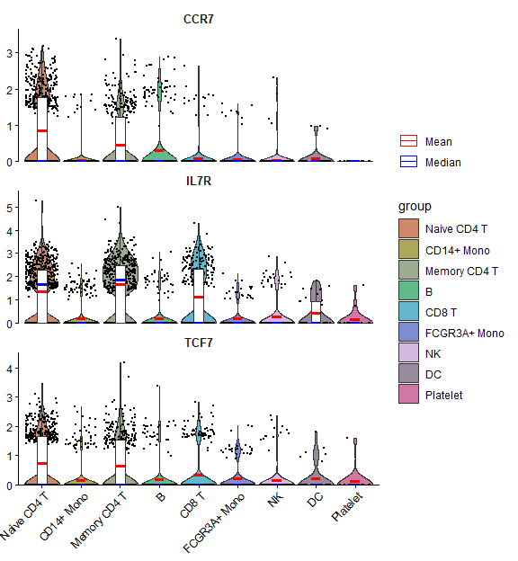

```r
lowExprGenes <- c("CCR7", "IL7R", "TCF7")
VlnPlot2(pbmc,
         features = lowExprGenes,
         show.mean = TRUE,      # Show mean and median lines
         mean_colors = c("red", "blue"),  # Colors for mean and median
         cols = "light",        # Light color scheme for better visibility
         ncol = 1)
```

### Split Visualization

You can group by cluster and split each cluster by samples:

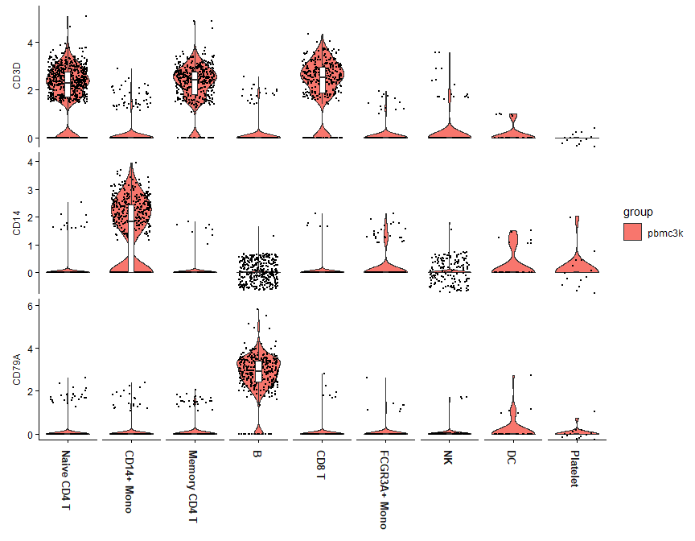

```r
VlnPlot2(pbmc,
         features = genes,
         group.by = "cluster",
         split.by = "orig.ident")
```

### Subset Analysis

You can focus on specific cell types and arrange plots in columns:

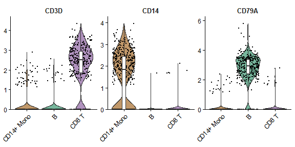

```r
cells <- colnames(pbmc)[pbmc$cluster %in% c("B", "CD14+ Mono", "CD8 T")]
VlnPlot2(pbmc,
         features = genes,
         group.by = "cluster",
         cells = cells)
```

### Statistical Analysis

Add statistical annotations using the Wilcoxon test, hiding non-significant results:

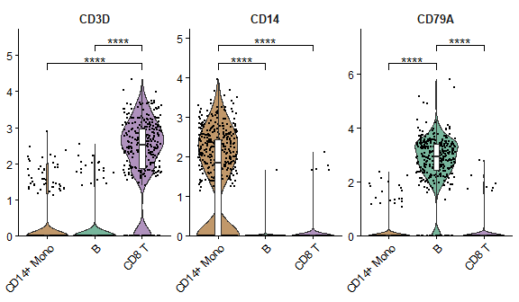

```r
VlnPlot2(
  pbmc,
  features = genes,
  group.by = "cluster",
  cells = cells,
  stat.method = "wilcox.test",
  hide.ns = TRUE
)
```

Or specify particular comparisons using t-test:

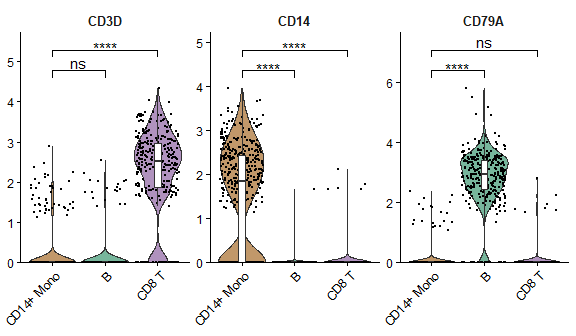

```r
VlnPlot2(
  pbmc,
  features = genes,
  group.by = "cluster",
  cells = cells,
  stat.method = "t.test",
  comparisons = list(c(1, 2), c(1, 3)),
  hide.ns = FALSE
)
```

### Using Matrix Input

You can also use `VlnPlot2` with matrices, such as AUCell scores from gene set enrichment analysis:

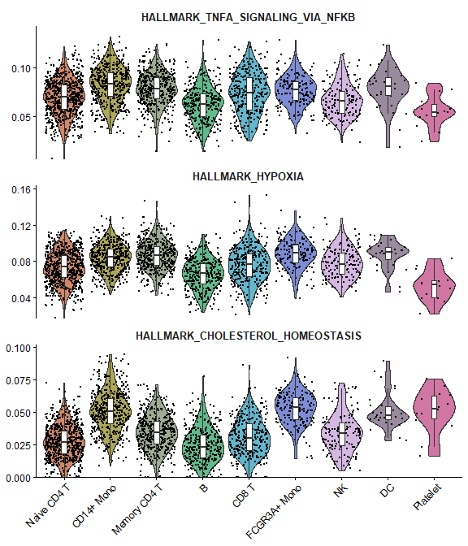

```r
# Perform gene set analysis
pbmc <- GeneSetAnalysis(pbmc, genesets = hall50$human)
matr <- pbmc@misc$AUCell$genesets

# Plot the first three pathways
VlnPlot2(matr[1:3, ], f = pbmc$cluster, ncol = 1)
```

> **Note on Statistical Testing:** When using `stat.method` to add statistical annotations to violin plots, be aware that p-values can be artificially inflated in large single-cell datasets due to the high number of cells. This may result in statistically significant differences (small p-values) even when the biological effect size is minimal. We recommend being cautious with statistical interpretations, especially when visual differences are subtle. Consider examining log fold changes (logFC) between groups to better assess the magnitude of biological differences. Additionally, the percentage of cells expressing a marker (similar to the pct.1 and pct.2 values in Seurat’s FindMarkers) is an important metric - if the difference in percentage between groups is minimal, the expression difference may be biologically negligible despite a significant p-value. Parameters like min.pct in differential expression analysis can help filter out features with low expression prevalence. For a comprehensive visualization of differences between two groups, `WaterfallPlot()` (see Generate a Waterfall Plot) can provide logFC values along with statistical significance. By default, `VlnPlot2` uses the Holm method (`p.adjust.method = "holm"`) to adjust p-values for multiple comparisons.

## Visualize Cluster Distribution in Samples

### Introduction

The `ClusterDistrBar` function visualizes how clusters are distributed across different samples. It can show both absolute counts and proportions, with various customization options.

### Basic Usage

Create a basic bar plot showing cluster distribution within samples:

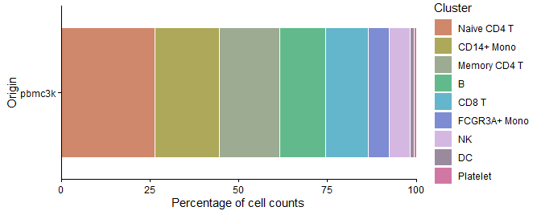

```r
ClusterDistrBar(origin = pbmc$orig.ident, cluster = pbmc$cluster)
```

### Absolute Cell Counts

To show absolute cell counts instead of proportions:

```r
ClusterDistrBar(
  origin = pbmc$orig.ident,
  cluster = pbmc$cluster,
  percent = FALSE
)
```

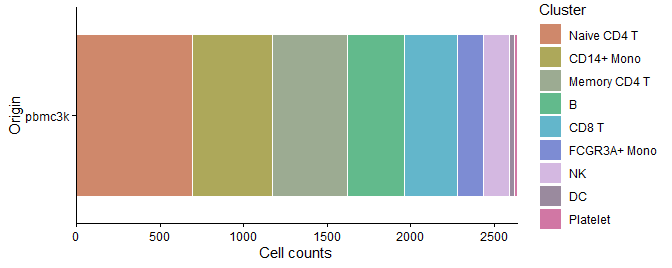

### Normalized Proportions with Reversed Axes

For normalized data with reversed axes:

```r
# ClusterDistrBar(origin = pbmc$orig.ident, cluster = pbmc$cluster, rev = TRUE, normalize = TRUE)
```

### Vertical Orientation

Create a vertical bar plot:

```r
ClusterDistrBar(
  origin = pbmc$orig.ident,
  cluster = pbmc$cluster,
  flip = FALSE,
  reverse_order = FALSE
)
```

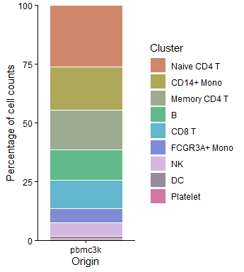

### Non-Stacked Display

Show bars side by side instead of stacked:

```r
ClusterDistrBar(
  origin = pbmc$orig.ident,
  cluster = pbmc$cluster,
  flip = FALSE,
  stack = FALSE
)
```

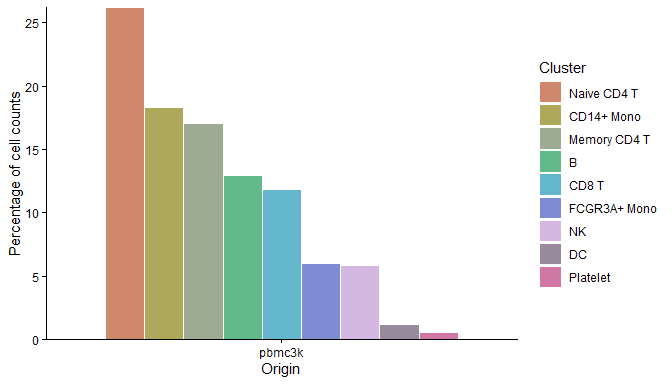

### Comparing Cluster Distribution Between Conditions (New in v1.2.0)

For comparing cluster distribution patterns between experimental conditions, `SeuratExtend` offers the `ClusterDistrPlot` function. This function extends `ClusterDistrBar` functionality by adding the ability to group samples by a condition variable, creating boxplots grouped by condition instead of stacked bars.

The function supports all parameters from `ClusterDistrBar` when using the standard bar plot mode, and inherits styling options from `VlnPlot2` when using the boxplot mode with conditions. This makes it highly versatile for different visualization needs.

```r
# # Compare cluster distribution between conditions
# ClusterDistrPlot(
#   origin = pbmc$sample_id,
#   cluster = pbmc$cluster,
#   condition = pbmc$condition
# )
```

When the `condition` parameter is not provided, `ClusterDistrPlot` behaves exactly like `ClusterDistrBar`, providing seamless backward compatibility.

## Generate a Waterfall Plot

### Introduction

Waterfall plots are powerful tools for visualizing differences between two conditions, effectively displaying metrics like gene expression differences or pathway enrichment scores. Note that starting from v1.1.0, similar to other visualization functions, the default color scheme has been updated to use more vibrant RColorBrewer palettes.

### Basic Usage

First, let’s create a matrix using the `GeneSetAnalysis()` function:

```r
pbmc <- GeneSetAnalysis(pbmc, genesets = hall50$human)
matr <- pbmc@misc$AUCell$genesets
str(matr)
```

```
##  num [1:48, 1:2638] 0.1016 0.09272 0.02363 0.00286 0.01119 ...
##  - attr(*, "dimnames")=List of 2
##   ..$ gene sets: chr [1:48] "HALLMARK_TNFA_SIGNALING_VIA_NFKB" "HALLMARK_HYPOXIA" "HALLMARK_CHOLESTEROL_HOMEOSTASIS" "HALLMARK_MITOTIC_SPINDLE" ...
##   ..$ cells    : chr [1:2638] "AAACATACAACCAC-1" "AAACATTGAGCTAC-1" "AAACATTGATCAGC-1" "AAACCGTGCTTCCG-1" ...
```

```r
head(matr)
```

[output not shown]

[output cut: 10497 more lines]

[output not shown]

Generate a basic waterfall plot comparing two cell types:

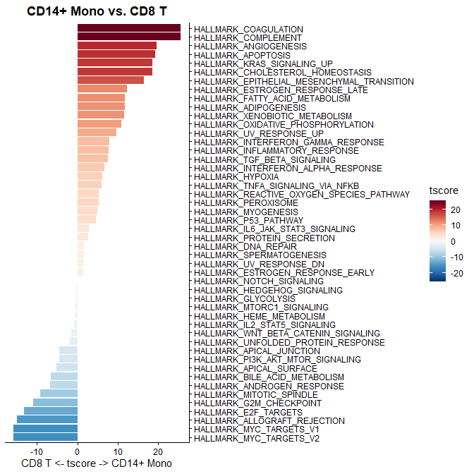

```r
WaterfallPlot(matr,
              f = pbmc$cluster,
              ident.1 = "CD14+ Mono",
              ident.2 = "CD8 T")
```

### WaterfallPlot Style: “segment” (New in v1.1.0)

Added a new visualization style “segment” to WaterfallPlot, providing an alternative way to display differences between conditions:

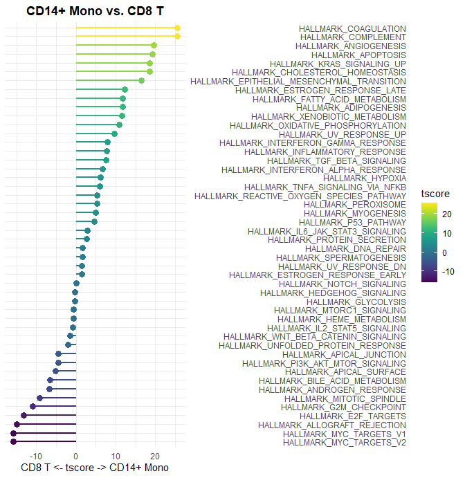

```r
# Create a plot using the new segment style
WaterfallPlot(
  matr,
  f = pbmc$cluster,
  ident.1 = "CD14+ Mono",
  ident.2 = "CD8 T",
  style = "segment",
  color_theme = "D"
)
```

### Filtering by Significance

Focus on significant differences by setting a threshold:

```
## Ignoring unknown labels:
## • colour : "tscore"
```

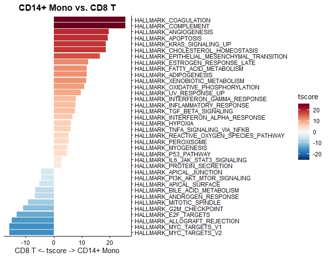

```r
WaterfallPlot(
  matr,
  f = pbmc$cluster,
  ident.1 = "CD14+ Mono",
  ident.2 = "CD8 T",
  len.threshold = 2)
```

### Gene Expression Comparison

Compare expression levels directly from a Seurat object:

```
## Using pseudocount = 1 for logFC calculation.
```

```
## Ignoring unknown labels:
## • colour : "-log10(p)"
```

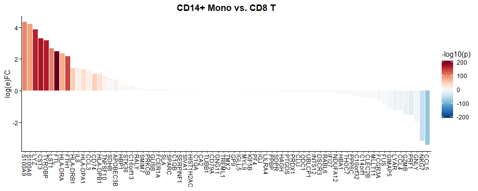

```r
genes <- VariableFeatures(pbmc)[1:80]
WaterfallPlot(
  pbmc,
  group.by = "cluster",
  features = genes,
  ident.1 = "CD14+ Mono",
  ident.2 = "CD8 T",
  length = "logFC")
```

### Focusing on Top Features

Display only the most differentially expressed genes:

```
## Using pseudocount = 1 for logFC calculation.
```

```
## Ignoring unknown labels:
## • colour : "-log10(p)"
```

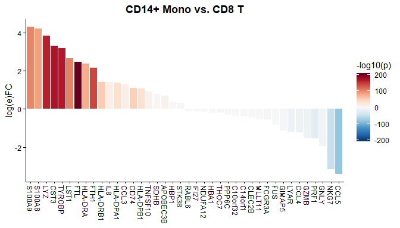

```r
WaterfallPlot(
  pbmc,
  group.by = "cluster",
  features = genes,
  ident.1 = "CD14+ Mono",
  ident.2 = "CD8 T",
  length = "logFC",
  top.n = 20)
```